# Future 500 Challenge - Da forma tidy

Vinícius Salustiano

# 1 Proposta do desafio

A partir dos dados fornecidos pela revista fictícia Future-500, produzir os seguintes gráficos:

- Gráfico de dispersão exibindo receita, gastos e lucros, classificado por indústria
- Gráfico de dispersão incluindo tendências para a relação gastos~receita por indústria
- Boxplots com crescimento por indústria

Ressalta-se que se necessitará primeiro tratar o dataset (valores ausentes, outliers, etc.) para se chegar ao produto demandado.

O arquivo csv está disponível no seguinte [endereço](https://www.superdatascience.com/rcourse-advanced/).

# 2 A base de dados

Lemos o arquivo csv pela função **read_csv** do pacote `readr` e exibimos o dataset para um primeiro contato com suas características principais.

Utilizaremos nesta primeira visualização, e nas próximas, o pacote `kableExtra` para a renderização das tabelas no presente relatório. Para mais informações sobre sua sintaxe, consultar esta [página](https://cran.r-project.org/web/packages/kableExtra/vignettes/awesome_table_in_html.html)

| ID | Name | Industry | Inception | Employees | State | City | Revenue | Expenses | Profit | Growth |
| --- | --- | --- | --- | --- | --- | --- | --- | --- | --- | --- |
| 1 | Over-Hex | Software | 2006 | 25 | TN | Franklin | $9,684,527 | 1,130,700 Dollars | 8553827 | 19% |
| 2 | Unimattax | IT Services | 2009 | 36 | PA | Newtown Square | $14,016,543 | 804,035 Dollars | 13212508 | 20% |
| 3 | Greenfax | Retail | 2012 | NA | SC | Greenville | $9,746,272 | 1,044,375 Dollars | 8701897 | 16% |
| 4 | Blacklane | IT Services | 2011 | 66 | CA | Orange | $15,359,369 | 4,631,808 Dollars | 10727561 | 19% |
| 5 | Yearflex | Software | 2013 | 45 | WI | Madison | $8,567,910 | 4,374,841 Dollars | 4193069 | 19% |
| 6 | Indigoplanet | IT Services | 2013 | 60 | NJ | Manalapan | $12,805,452 | 4,626,275 Dollars | 8179177 | 22% |
| 7 | Treslam | Financial Services | 2009 | 116 | MO | Clayton | $5,387,469 | 2,127,984 Dollars | 3259485 | 17% |
| 8 | Rednimdox | Construction | 2013 | 73 | NY | Woodside | NA | NA | NA | NA |
| 9 | Lamtone | IT Services | 2009 | 55 | CA | San Ramon | $11,757,018 | 6,482,465 Dollars | 5274553 | 30% |
| 10 | Stripfind | Financial Services | 2010 | 25 | FL | Boca Raton | $12,329,371 | 916,455 Dollars | 11412916 | 20% |
| 11 | Canecorporation | Health | 2012 | 6 | NA | New York | $10,597,009 | 7,591,189 Dollars | 3005820 | 7% |
| 12 | Mattouch | IT Services | 2013 | 6 | WA | Bellevue | $14,026,934 | 7,429,377 Dollars | 6597557 | 26% |
| 13 | Techdrill | Health | 2009 | 9 | MS | Flowood | $10,573,990 | 7,435,363 Dollars | 3138627 | 8% |
| 14 | Techline | NA | 2006 | 65 | CA | San Ramon | $13,898,119 | 5,470,303 Dollars | 8427816 | 23% |
| 15 | Cityace | NA | 2010 | 25 | CO | Louisville | $9,254,614 | 6,249,498 Dollars | 3005116 | 6% |
| 16 | Kayelectronics | Health | 2009 | 687 | NC | Clayton | $9,451,943 | 3,878,113 Dollars | 5573830 | 4% |
| 17 | Ganzlax | IT Services | 2011 | 75 | NJ | Iselin | $14,001,180 | NA | 11901180 | 18% |
| 18 | Trantraxlax | Government Services | 2011 | 35 | VA | Suffolk | $11,088,336 | 5,635,276 Dollars | 5453060 | 7% |
| 19 | E-Zim | Retail | 2008 | 320 | OH | Monroe | $10,746,451 | 4,762,319 Dollars | 5984132 | 13% |
| 20 | Daltfase | Software | 2011 | 78 | NC | Durham | $10,410,628 | 6,196,409 Dollars | 4214219 | 17% |
| 21 | Hotlane | Government Services | 2012 | 87 | AL | Huntsville | $7,978,332 | 5,686,574 Dollars | 2291758 | 2% |
| 22 | Lathotline | Health | NA | 103 | VA | McLean | $9,418,303 | 7,567,233 Dollars | 1851070 | 2% |
| 23 | Lambam | IT Services | 2012 | 210 | SC | Columbia | $11,950,148 | 4,365,512 Dollars | 7584636 | 20% |
| 24 | Quozap | Software | 2004 | 21 | NJ | Collingswood | $8,304,480 | 7,019,973 Dollars | 1284507 | 20% |
| 25 | Tampware | Construction | 2011 | 13 | TX | Houston | $9,785,982 | 2,910,756 Dollars | 6875226 | 11% |
| 26 | Dalthow | Health | 2000 | 20 | GA | Dacula | $10,800,718 | 7,731,820 Dollars | 3068898 | 7% |
| 27 | Ranktech | Government Services | 2010 | 607 | FL | Tampa | $10,515,557 | 7,439,384 Dollars | 3076173 | 8% |
| 28 | Unadex | Software | 2013 | 280 | NC | Cary | $5,231,275 | 2,388,521 Dollars | 2842754 | 19% |
| 29 | Groovecane | Construction | 2011 | 17 | UT | South Jordan | $6,811,168 | 3,560,343 Dollars | 3250825 | 15% |
| 30 | Tambase | Software | 2010 | 29 | AZ | Scottsdale | $9,141,817 | 2,394,135 Dollars | 6747682 | 21% |

[output cut: 470 more lines]

# 3 Identificando inconsistências

## 3.1 Colunas *Revenue*, *Expenses* e *Growth*

Um primeiro ponto que chama a atenção é a formatação das colunas Revenue, Expenses e Growth, que se referemm a valores numéricos mas, por sua natureza monetária, foram gravados no dataset original com signos como “Dollars”, “$” e “%”, e foram lidas contendo valores textuais no carregamento default.

Não exibimos anteriormente, mas vale ressaltar uma funcionalidade da função `read_csv` que retorna como cada coluna foi interpretada, facilitando também o trabalho de análise.

Outra funcionalidade importante de `read_csv` é a sua facilidade em converter essas usuais formatações alternativas de números no formato adequado.

Faremos, portanto, novamente a leitura do arquivo csv, ajustando o tipo das colunas referidas.

| ID | Name | Industry | Inception | Employees | State | City | Revenue | Expenses | Profit | Growth |
| --- | --- | --- | --- | --- | --- | --- | --- | --- | --- | --- |
| 1 | Over-Hex | Software | 2006 | 25 | TN | Franklin | 9684527 | 1130700 | 8553827 | 19 |
| 2 | Unimattax | IT Services | 2009 | 36 | PA | Newtown Square | 14016543 | 804035 | 13212508 | 20 |
| 3 | Greenfax | Retail | 2012 | NA | SC | Greenville | 9746272 | 1044375 | 8701897 | 16 |
| 4 | Blacklane | IT Services | 2011 | 66 | CA | Orange | 15359369 | 4631808 | 10727561 | 19 |
| 5 | Yearflex | Software | 2013 | 45 | WI | Madison | 8567910 | 4374841 | 4193069 | 19 |
| 6 | Indigoplanet | IT Services | 2013 | 60 | NJ | Manalapan | 12805452 | 4626275 | 8179177 | 22 |
| 7 | Treslam | Financial Services | 2009 | 116 | MO | Clayton | 5387469 | 2127984 | 3259485 | 17 |
| 8 | Rednimdox | Construction | 2013 | 73 | NY | Woodside | NA | NA | NA | NA |
| 9 | Lamtone | IT Services | 2009 | 55 | CA | San Ramon | 11757018 | 6482465 | 5274553 | 30 |
| 10 | Stripfind | Financial Services | 2010 | 25 | FL | Boca Raton | 12329371 | 916455 | 11412916 | 20 |
| 11 | Canecorporation | Health | 2012 | 6 | NA | New York | 10597009 | 7591189 | 3005820 | 7 |
| 12 | Mattouch | IT Services | 2013 | 6 | WA | Bellevue | 14026934 | 7429377 | 6597557 | 26 |
| 13 | Techdrill | Health | 2009 | 9 | MS | Flowood | 10573990 | 7435363 | 3138627 | 8 |
| 14 | Techline | NA | 2006 | 65 | CA | San Ramon | 13898119 | 5470303 | 8427816 | 23 |
| 15 | Cityace | NA | 2010 | 25 | CO | Louisville | 9254614 | 6249498 | 3005116 | 6 |
| 16 | Kayelectronics | Health | 2009 | 687 | NC | Clayton | 9451943 | 3878113 | 5573830 | 4 |
| 17 | Ganzlax | IT Services | 2011 | 75 | NJ | Iselin | 14001180 | NA | 11901180 | 18 |
| 18 | Trantraxlax | Government Services | 2011 | 35 | VA | Suffolk | 11088336 | 5635276 | 5453060 | 7 |
| 19 | E-Zim | Retail | 2008 | 320 | OH | Monroe | 10746451 | 4762319 | 5984132 | 13 |
| 20 | Daltfase | Software | 2011 | 78 | NC | Durham | 10410628 | 6196409 | 4214219 | 17 |
| 21 | Hotlane | Government Services | 2012 | 87 | AL | Huntsville | 7978332 | 5686574 | 2291758 | 2 |
| 22 | Lathotline | Health | NA | 103 | VA | McLean | 9418303 | 7567233 | 1851070 | 2 |
| 23 | Lambam | IT Services | 2012 | 210 | SC | Columbia | 11950148 | 4365512 | 7584636 | 20 |
| 24 | Quozap | Software | 2004 | 21 | NJ | Collingswood | 8304480 | 7019973 | 1284507 | 20 |
| 25 | Tampware | Construction | 2011 | 13 | TX | Houston | 9785982 | 2910756 | 6875226 | 11 |
| 26 | Dalthow | Health | 2000 | 20 | GA | Dacula | 10800718 | 7731820 | 3068898 | 7 |
| 27 | Ranktech | Government Services | 2010 | 607 | FL | Tampa | 10515557 | 7439384 | 3076173 | 8 |
| 28 | Unadex | Software | 2013 | 280 | NC | Cary | 5231275 | 2388521 | 2842754 | 19 |
| 29 | Groovecane | Construction | 2011 | 17 | UT | South Jordan | 6811168 | 3560343 | 3250825 | 15 |
| 30 | Tambase | Software | 2010 | 29 | AZ | Scottsdale | 9141817 | 2394135 | 6747682 | 21 |

[output cut: 470 more lines]

## 3.2 Coluna Industry

Uma hipótese é de que a coluna Industry é uma variável categórica de nosso dataset e, portanto, deveria ser convertida para `factor`, de modo a facilitar nossas análises posteriores.

Será que essa hipótese se sustenta? Uma maneira rápida é exibindo a tabela de frequência de valores desta coluna, como abaixo:

| Industry | Frequency |
| --- | --- |
| Construction | 50 |
| Financial Services | 54 |
| Government Services | 50 |
| Health | 86 |
| IT Services | 146 |
| Retail | 48 |
| Software | 64 |

Podemos sim afirmar, conforme visualização acima, que a coluna Industry contém variável categórica, com 7 valores assumidos: Construction, Financial Services, Government Services, Health, IT Services, Retail, Software.

Leremos novamente o dataset ajustando portanto o tipo de leitura para essa coluna também (e que será o último ajuste de leitura - os demais serão efeturados já sobre os dados importados).

| ID | Name | Industry | Inception | Employees | State | City | Revenue | Expenses | Profit | Growth |
| --- | --- | --- | --- | --- | --- | --- | --- | --- | --- | --- |
| 1 | Over-Hex | Software | 2006 | 25 | TN | Franklin | 9684527 | 1130700 | 8553827 | 19 |
| 2 | Unimattax | IT Services | 2009 | 36 | PA | Newtown Square | 14016543 | 804035 | 13212508 | 20 |
| 3 | Greenfax | Retail | 2012 | NA | SC | Greenville | 9746272 | 1044375 | 8701897 | 16 |
| 4 | Blacklane | IT Services | 2011 | 66 | CA | Orange | 15359369 | 4631808 | 10727561 | 19 |
| 5 | Yearflex | Software | 2013 | 45 | WI | Madison | 8567910 | 4374841 | 4193069 | 19 |
| 6 | Indigoplanet | IT Services | 2013 | 60 | NJ | Manalapan | 12805452 | 4626275 | 8179177 | 22 |
| 7 | Treslam | Financial Services | 2009 | 116 | MO | Clayton | 5387469 | 2127984 | 3259485 | 17 |
| 8 | Rednimdox | Construction | 2013 | 73 | NY | Woodside | NA | NA | NA | NA |
| 9 | Lamtone | IT Services | 2009 | 55 | CA | San Ramon | 11757018 | 6482465 | 5274553 | 30 |
| 10 | Stripfind | Financial Services | 2010 | 25 | FL | Boca Raton | 12329371 | 916455 | 11412916 | 20 |
| 11 | Canecorporation | Health | 2012 | 6 | NA | New York | 10597009 | 7591189 | 3005820 | 7 |
| 12 | Mattouch | IT Services | 2013 | 6 | WA | Bellevue | 14026934 | 7429377 | 6597557 | 26 |
| 13 | Techdrill | Health | 2009 | 9 | MS | Flowood | 10573990 | 7435363 | 3138627 | 8 |
| 14 | Techline | NA | 2006 | 65 | CA | San Ramon | 13898119 | 5470303 | 8427816 | 23 |
| 15 | Cityace | NA | 2010 | 25 | CO | Louisville | 9254614 | 6249498 | 3005116 | 6 |
| 16 | Kayelectronics | Health | 2009 | 687 | NC | Clayton | 9451943 | 3878113 | 5573830 | 4 |
| 17 | Ganzlax | IT Services | 2011 | 75 | NJ | Iselin | 14001180 | NA | 11901180 | 18 |
| 18 | Trantraxlax | Government Services | 2011 | 35 | VA | Suffolk | 11088336 | 5635276 | 5453060 | 7 |
| 19 | E-Zim | Retail | 2008 | 320 | OH | Monroe | 10746451 | 4762319 | 5984132 | 13 |
| 20 | Daltfase | Software | 2011 | 78 | NC | Durham | 10410628 | 6196409 | 4214219 | 17 |
| 21 | Hotlane | Government Services | 2012 | 87 | AL | Huntsville | 7978332 | 5686574 | 2291758 | 2 |
| 22 | Lathotline | Health | NA | 103 | VA | McLean | 9418303 | 7567233 | 1851070 | 2 |
| 23 | Lambam | IT Services | 2012 | 210 | SC | Columbia | 11950148 | 4365512 | 7584636 | 20 |
| 24 | Quozap | Software | 2004 | 21 | NJ | Collingswood | 8304480 | 7019973 | 1284507 | 20 |
| 25 | Tampware | Construction | 2011 | 13 | TX | Houston | 9785982 | 2910756 | 6875226 | 11 |
| 26 | Dalthow | Health | 2000 | 20 | GA | Dacula | 10800718 | 7731820 | 3068898 | 7 |
| 27 | Ranktech | Government Services | 2010 | 607 | FL | Tampa | 10515557 | 7439384 | 3076173 | 8 |
| 28 | Unadex | Software | 2013 | 280 | NC | Cary | 5231275 | 2388521 | 2842754 | 19 |
| 29 | Groovecane | Construction | 2011 | 17 | UT | South Jordan | 6811168 | 3560343 | 3250825 | 15 |
| 30 | Tambase | Software | 2010 | 29 | AZ | Scottsdale | 9141817 | 2394135 | 6747682 | 21 |

[output cut: 470 more lines]

## 3.3 Valores ausentes

Como já pudemos registrar, há valores ausentes para algumas observações. Identifiquemos quais colunas possuem observações ausentes e, em um segundo momento, as quantifiquemos.

|  | Valor Ausente |
| --- | --- |
| ID | FALSE |
| Name | FALSE |
| Industry | TRUE |
| Inception | TRUE |
| Employees | TRUE |
| State | TRUE |
| City | FALSE |
| Revenue | TRUE |
| Expenses | TRUE |
| Profit | TRUE |
| Growth | TRUE |

Uma forma rápida de identificamos a quantidade de valores ausentes por coluna é sumarizando o dataset, como abaixo.

```
##        ID            Name                         Industry
##  Min.   :  1.0   Length:500         IT Services       :146
##  1st Qu.:125.8   Class :character   Health            : 86
##  Median :250.5   Mode  :character   Software          : 64
##  Mean   :250.5                      Financial Services: 54
##  3rd Qu.:375.2                      Construction      : 50
##  Max.   :500.0                      (Other)           : 98
##                                     NA's              :  2
##    Inception      Employees          State               City
##  Min.   :1999   Min.   :   1.00   Length:500         Length:500
##  1st Qu.:2009   1st Qu.:  27.25   Class :character   Class :character
##  Median :2011   Median :  56.00   Mode  :character   Mode  :character
##  Mean   :2010   Mean   : 148.61
##  3rd Qu.:2012   3rd Qu.: 126.00
##  Max.   :2014   Max.   :7125.00
##  NA's   :1      NA's   :2
##     Revenue            Expenses           Profit             Growth
##  Min.   : 1614585   Min.   :  71219   Min.   :   12434   Min.   :-3.00
##  1st Qu.: 8695702   1st Qu.:2758425   1st Qu.: 3272074   1st Qu.: 8.00
##  Median :10647231   Median :4365512   Median : 6513366   Median :15.00
##  Mean   :10845170   Mean   :4310134   Mean   : 6539474   Mean   :14.38
##  3rd Qu.:13106928   3rd Qu.:5832473   3rd Qu.: 9303951   3rd Qu.:20.00
##  Max.   :21810051   Max.   :9860686   Max.   :19624534   Max.   :30.00
##  NA's   :2          NA's   :3         NA's   :2          NA's   :1
```

Podemos, portanto, pela pouca quantidade de valores ausentes, num primeiro momento não tratá-los e apenas nos precaver ao utilizar funções sumário, utilizando o argumento `na.rm = TRUE`.

# 4 Resumo estatístico

## 4.1 Distribuição de receitas, gastos, lucro e crescimento

Abaixo, visualizaremos como se distribuem receitas, gastos, lucro e crescimento por indústria.

### 4.1.1 Receita

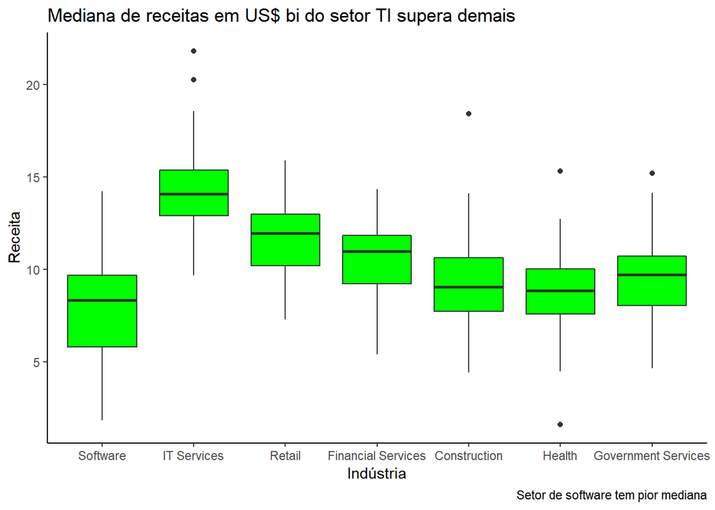

### 4.1.2 Gastos

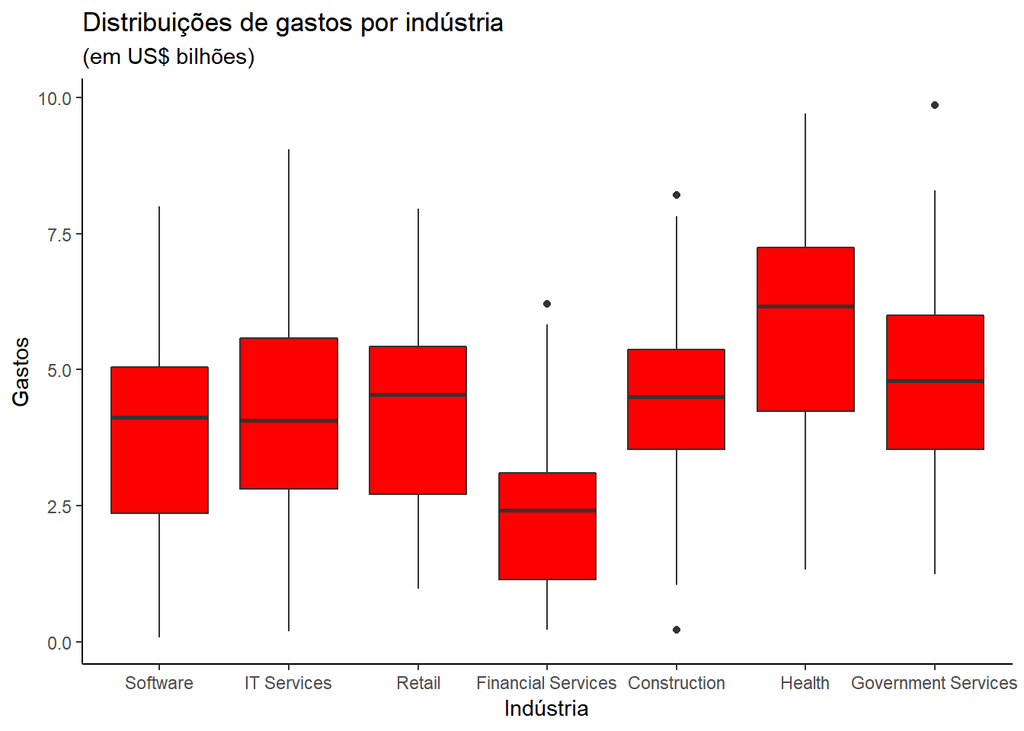

### 4.1.3 Lucro

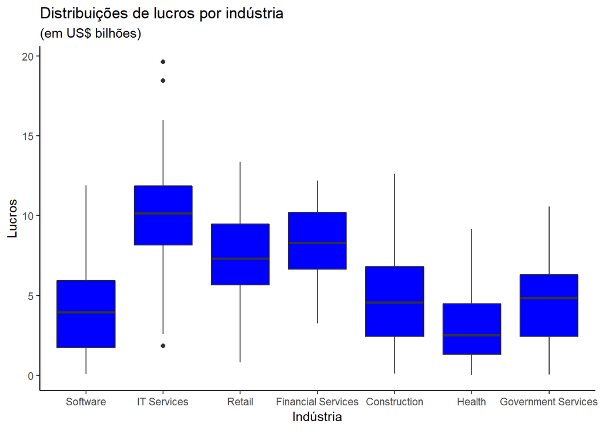

### 4.1.4 Crescimento

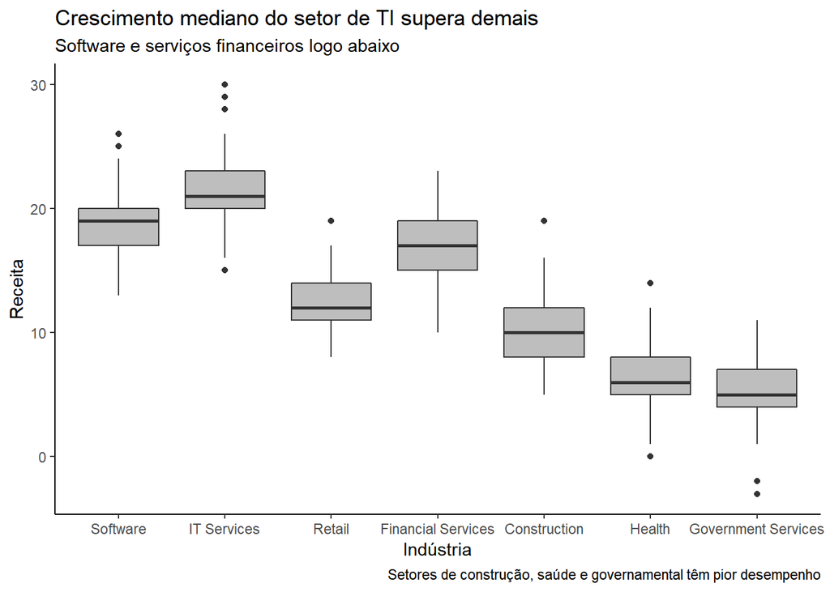

# 5 Gráficos de dispersão

## 5.1 Receitas por gastos por indústria

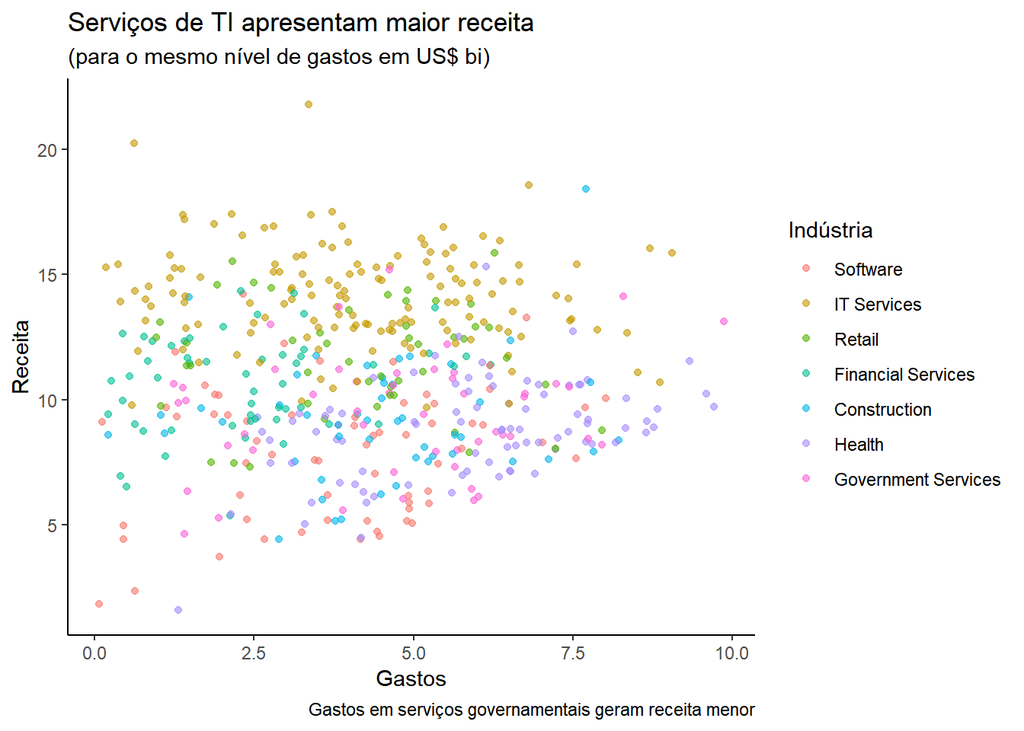

Exibimos acima gráfico de dispersão de receita e gastos, classificados por indústria.

Pode-se ver que, para mesmos níveis de gastos, a indústria de serviços de TI possui maiores receitas. Serviços governamentais, por outro lado, geram menor receita para um nível de gastos, o que constitui um argumento para defender sua utilização apenas em situações de falha de mercado.

## 5.2 Lucros por gastos por indústria

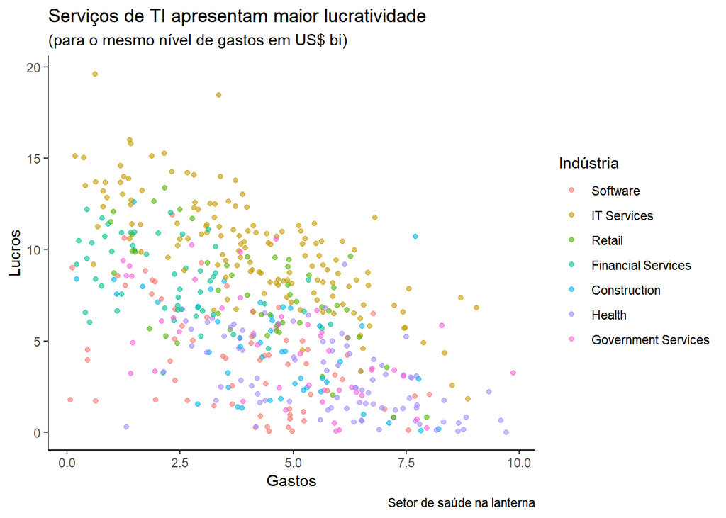

Exibimos acima gráfico de dispersão de lucro e gastos, classificados por indústria.

Pode-se ver que, para mesmos níveis de gastos, a indústria de serviços de TI possui maior lucratividade. Serviços de saúde, por outro lado, geram menor lucro para um nível de gastos.

Para todos os setores, a lucratividade e o gastos apresentam uma relação negativa.

## 5.3 Lucros por receita por indústria

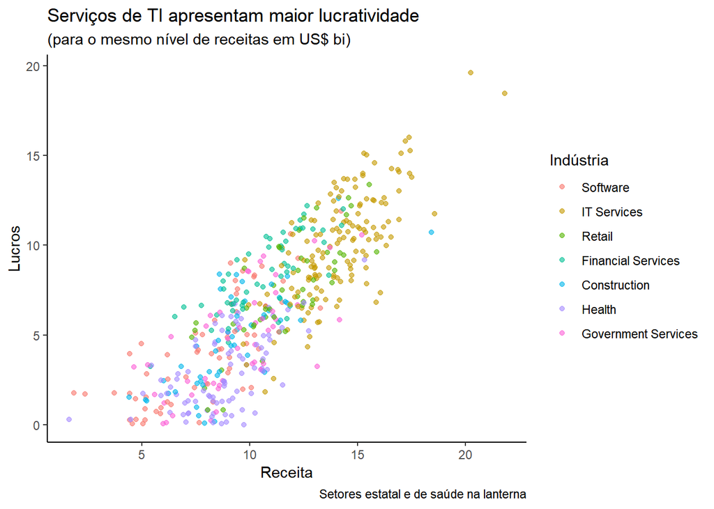

De uma forma geral, quanto mais receitas, maior a lucratividade para os setores analisados.